# A2

Andrew Wong

2025-03-18

```r
# References for each of these packages in References

if (!requireNamespace("ggrepel", quietly = TRUE)) {
  install.packages("ggrepel")
}
library(circlize)
library(ComplexHeatmap)
library(dplyr)
library(edgeR)
library(ggplot2)
library(ggrepel)
library(gprofiler2)
library(knitr)
library(kableExtra)

setwd("/home/rstudio/projects")
```

# Introduction

The dataset I will use in this report is the same one I prepared in Assignment 1, originating from the Diet-omics Study of Urban and Rural Crohn Disease Evolution (SOURCE) cohort, with GEO accession ID GSE233900. In the original study, the investigators examined how environmental, dietary, and microbial factors may interact with the human host transcriptome, particularly in the pathogenesis of Crohn’s disease (CD). Their analysis covered 380 participants across rural and urban regions of China and Israel, capturing both dietary habits and clinical parameters [1, 2]. From this broader cohort, 40 ileal tissue biopsy samples (20 from patients with Crohn’s disease and 20 from non-CD controls) were profiled by RNA-seq, resulting in a dataset that includes both annotated clinical metadata and raw count data.

In Assignment 1, I downloaded the raw RNA-seq counts, filtered out genes with extremely low expression (fewer than 1 CPM in at least 4 samples), mapped remaining genes to HUGO symbols using biomaRt, and normalized the counts via the Trimmed Mean of M-values (TMM) method from edgeR [3, 4]. I subsequently removed transcripts that lacked a valid HGNC symbol or were duplicates of the same gene, ending with a final dataset of 16,408 genes across the 40 samples. This final processed dataset—along with the truncated sample annotations focusing on disease status (CD vs. non-CD), patient group, age, and sex—was saved in two files:

A1_normalized_counts.RData: contains a data frame named final_normalized_counts (16,408 rows x 40 columns), where each row corresponds to a unique HGNC symbol and each column corresponds to a sample’s TMM-normalized expression values.

A1_truncated_sample_annotations.RData: contains a data frame named sample_metadata (40 rows x 4 columns), storing attributes such as diagnosis (CD or Control), patient_group (Rural, Urban, or CD), sex (male/female), and age.

Below is a code snippet demonstrating how I load these final data objects from A1. This code will serve as the foundation for further steps in Assignment 2.

```r
# (40 x 4 data frame named sample_metadata in A1)
load("A1_truncated_sample_annotations.RData")

# (16,408 x 40 data frame named final_normalized_counts in A1)
load("A1_normalized_counts.RData")

cat("Dimensions of sample_metadata:", dim(sample_metadata), "\n")
```

```
## Dimensions of sample_metadata: 40 4
```

```r
head(sample_metadata)
```

```
##            diagnosis patient_group    sex age
## GSM7438854   Control         Urban   male  38
## GSM7438855   Control         Urban   male  52
## GSM7438856   Control         Urban female  47
## GSM7438857   Control         Urban   male  41
## GSM7438858   Control         Urban female  31
## GSM7438859   Control         Urban female  36
```

The sample metadata appears to be the same as A1, lets look at the normalized count data.

```r
cat("\nDimensions of final_normalized_counts:", dim(final_normalized_counts), "\n")
```

```
##
## Dimensions of final_normalized_counts: 16408 40
```

```r
head(final_normalized_counts[, 1:5])
```

```
##          GSM7438854 GSM7438855 GSM7438856 GSM7438857 GSM7438858
## A1BG       2.019090   1.767386   2.257911   1.796816   1.341846
## A1BG-AS1   1.710288   1.963762   0.752637   1.619665   1.236603
## A1CF     148.106202 178.309593 147.615018 172.620827 167.072938
## A2M      337.496860 157.914522 279.784617 413.470029 253.556205
## A2M-AS1   10.665547   6.003501  17.179757  16.095418   7.551171
## A4GALT     3.919410   4.067793   6.348329   3.593631   4.262333
```

The normalized count data looks good

```r
kable(sample_metadata, caption = "Table 1: Truncated sample annotations for GSE233900")
```

Table 1: Truncated sample annotations for GSE233900

|  | diagnosis | patient_group | sex | age |
| --- | --- | --- | --- | --- |
| GSM7438854 | Control | Urban | male | 38 |
| GSM7438855 | Control | Urban | male | 52 |
| GSM7438856 | Control | Urban | female | 47 |
| GSM7438857 | Control | Urban | male | 41 |
| GSM7438858 | Control | Urban | female | 31 |
| GSM7438859 | Control | Urban | female | 36 |
| GSM7438860 | Control | Urban | female | 38 |
| GSM7438861 | Control | Urban | female | 48 |
| GSM7438862 | Control | Urban | female | 36 |
| GSM7438863 | Control | Urban | female | 27 |
| GSM7438864 | Control | Urban | female | 38 |
| GSM7438865 | Control | Urban | male | 48 |
| GSM7438866 | Control | Urban | female | 38 |
| GSM7438867 | Control | Urban | male | 41 |
| GSM7438868 | Control | Urban | male | 25 |
| GSM7438869 | Control | Urban | female | 27 |
| GSM7438870 | Control | Urban | male | 28 |
| GSM7438871 | Control | Urban | male | 27 |
| GSM7438872 | Control | Urban | male | 32 |
| GSM7438873 | Control | Rural | female | 49 |
| GSM7438874 | CD | CD | male | 29 |
| GSM7438875 | CD | CD | female | 53 |
| GSM7438876 | CD | CD | female | 25 |
| GSM7438877 | CD | CD | male | 28 |
| GSM7438878 | CD | CD | male | 44 |
| GSM7438879 | CD | CD | female | 25 |
| GSM7438880 | CD | CD | female | 27 |
| GSM7438881 | CD | CD | male | 35 |
| GSM7438882 | CD | CD | female | 30 |
| GSM7438883 | CD | CD | male | 38 |
| GSM7438884 | CD | CD | male | 28 |
| GSM7438885 | CD | CD | female | 39 |
| GSM7438886 | CD | CD | female | 33 |
| GSM7438887 | CD | CD | male | 29 |
| GSM7438888 | CD | CD | male | 34 |
| GSM7438889 | CD | CD | female | 41 |
| GSM7438890 | CD | CD | female | 27 |
| GSM7438891 | CD | CD | female | 31 |
| GSM7438892 | CD | CD | male | 28 |
| GSM7438893 | CD | CD | male | 30 |

As seen above, there are 40 samples (rows) in sample_metadata, each annotated with the information needed for grouping (CD vs. Control). The final_normalized_counts data frame has 16,408 rows (each row a unique HGNC symbol) and 40 columns (each column corresponding to a sample). TMM normalization [4] was applied in Assignment 1, which corrects for compositional differences across libraries.

Note: GSM7438854 to GSM7438873 are control samples while GSM7438874 to GSM7438893 are CD samples.

Before differential expression analysis, lets examine how the samples cluster in the MDS plot from A1. The code below is modified from lecture [3].

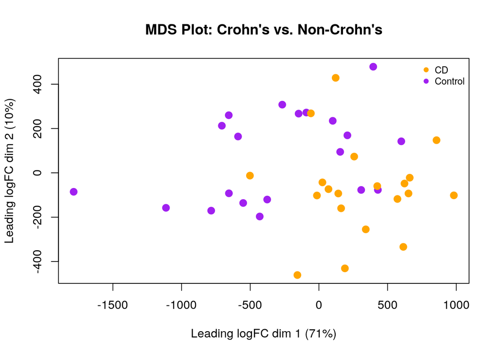

```r
# Visualizing how CD samples cluster relative to non-CD controls
# in the TMM-normalized data
limma::plotMDS(final_normalized_counts,
               labels = NULL,
               main   = "MDS Plot: Crohn's vs. Non-Crohn's",
               pch    = 19,
               cex    = 1.3,
               col    = c("orange","purple")[factor(sample_metadata$diagnosis)]
)

legend("topright",
       legend = levels(factor(sample_metadata$diagnosis)),
       pch    = 19,
       col    = c("orange","purple"),
       bty    = "n",
       cex    = 0.8
)
```

While there is some overlap between the two groups, the clustering pattern indicates that disease status has some influence on transcriptomic variation.

# Differential Gene Expression Analysis

```r
# Making sure Control is the baseline level
sample_metadata$diagnosis <- factor(sample_metadata$diagnosis,
                                    levels = c("Control", "CD"))
design_matrix <- model.matrix(~ sample_metadata$diagnosis)
design_matrix
```

```
##    (Intercept) sample_metadata$diagnosisCD
## 1            1                           0
## 2            1                           0
## 3            1                           0
## 4            1                           0
## 5            1                           0
## 6            1                           0
## 7            1                           0
## 8            1                           0
## 9            1                           0
## 10           1                           0
## 11           1                           0
## 12           1                           0
## 13           1                           0
## 14           1                           0
```

[output cut: 31 more lines]

As noted in class, the best differential expression test for our use case is likely `glmQLFit` as it provides more accurate type I error rate control and robustness to outliers for RNA-seq data than alternatives [3].

```r
# FITTING A QUASI-LIKELIHOOD NEGATIVE BINOMIAL GLM WITH EDGER
# Construct a DGEList using the TMM-normalized counts and diagnosis groups
dge_object <- DGEList(counts = as.matrix(final_normalized_counts),
                      group  = sample_metadata$diagnosis)

# Estimate dispersion parameters for the NB model
dge_object <- estimateDisp(dge_object, design_matrix)

# Fit a quasi-likelihood model
fit_qlm <- glmQLFit(dge_object, design_matrix)

# QL F-test comparing Crohn's Disease vs. Control

qlf_results <- glmQLFTest(fit_qlm, coef = "sample_metadata$diagnosisCD")

# Obtain all genes sorted by ascending p-value
qlf_sorted <- topTags(qlf_results,
                      sort.by = "PValue",
                      n       = nrow(final_normalized_counts))

# STORE THE RESULTS TABLE FOR DOWNSTREAM ANALYSIS
my_DE_results <- qlf_sorted$table
head(my_DE_results)
```

```
##            logFC   logCPM         F       PValue          FDR
## CXCL8   5.322574 4.189936 108.30165 4.426633e-16 5.298147e-12
## ALDH1A2 3.269491 2.335002 107.81521 6.458005e-16 5.298147e-12
## FCGR3B  5.627481 4.685126 102.21343 3.211478e-15 1.756464e-11
## C2CD4A  2.585294 2.419948  91.45416 3.312666e-14 1.358856e-10
## CXCR2   4.154052 3.297889  87.02549 5.176018e-14 1.698562e-10
## MYEOV   3.254630 2.409896  83.12684 1.040868e-13 2.846426e-10
```

Here, a positive log-fold change (logFC) indicates upregulation in CD samples relative to controls, whereas a negative logFC suggests downregulation in CD samples.

```r
# Count how many genes have raw p-value < 0.05
sum(my_DE_results$PValue < 0.05)
```

```
## [1] 8151
```

Out of the 16,408 genes analyzed, 8,151 (~49.7%) exhibit nominal significance (p-value < 0.05), suggesting transcriptomic differences between Crohn’s disease (CD) and control samples. While the samples did cluster somewhat well in the MDS plot, this number is unusually high. If most genes remain significant after correction, the result it suggests systemic dysregulation; however, if many genes lose significance after correction, this could indicate the need to consider confounding factors.

To apply a more stringent threshold, a threshold of 0.5 log fold change can be considered for more sensitive changes to analyze while a threshold of 1 can be used for higher confidence results [5]. Considering the high proportion of genes left, lets examine the threshold at 1.

```r
# log fold change > 1
sum(abs(my_DE_results$logFC) > 1)
```

```
## [1] 766
```

```r
sum(abs(my_DE_results$logFC) > 1 & (my_DE_results$PValue < 0.05))
```

```
## [1] 764
```

```r
# log fold change > 0.5
sum(abs(my_DE_results$logFC) > 0.5)
```

```
## [1] 3065
```

```r
sum(abs(my_DE_results$logFC) > 0.5 & (my_DE_results$PValue < 0.05))
```

```
## [1] 2961
```

With the more stringent threshold of |logFC| > 1, only 766 genes (~4.7% of 16,408) show a substantial expression change between Crohn’s disease (CD) and control samples. Among these, 764 genes (~4.7%) also pass the statistical significance threshold (p-value < 0.05). 766 genes meet the absolute log fold change threshold (|logFC| > 1) while 764 genes meet both the logFC and statistical significance (p-value < 0.05) thresholds. Testing at the threshold of |logFC| > 0.5, a similar proportion pass both thresholds 2961/3065 genes (~0.97). This high proportion of genes meeting the log fold change and p-value thresholds suggests that most genes with large expression differences are also statistically significant [5].

## Multiple Hypothesis Testing

We will be using the Benjamini-Hochberg correction to correct for false positives as it effectively controls the false discovery rate (FDR) when testing a large number of genes [3]. The cut off we will be using is 0.05 as noted in Benjamini and Hochberg’s original article [6]. While a cut off of 0.1 is tolerable, 0.05 continues to be standard practice and can provide higher confidence genes [7].

```r
# For safety, make a copy of DE_results
DE_table <- my_DE_results

DE_significant <- DE_table[DE_table$FDR < 0.05, ]

cat("Number of DE genes with FDR < 0.05:", nrow(DE_significant), "\n")
```

```
## Number of DE genes with FDR < 0.05: 6886
```

6886 pass the threshold from the 8151 genes. Given the relatively decent separation of genes Crohn’s and Control samples in the MDS plot, this is not completely unreasonable.

To examine this distribution with reference to genes instead of samples, we can produce a volcano plot.

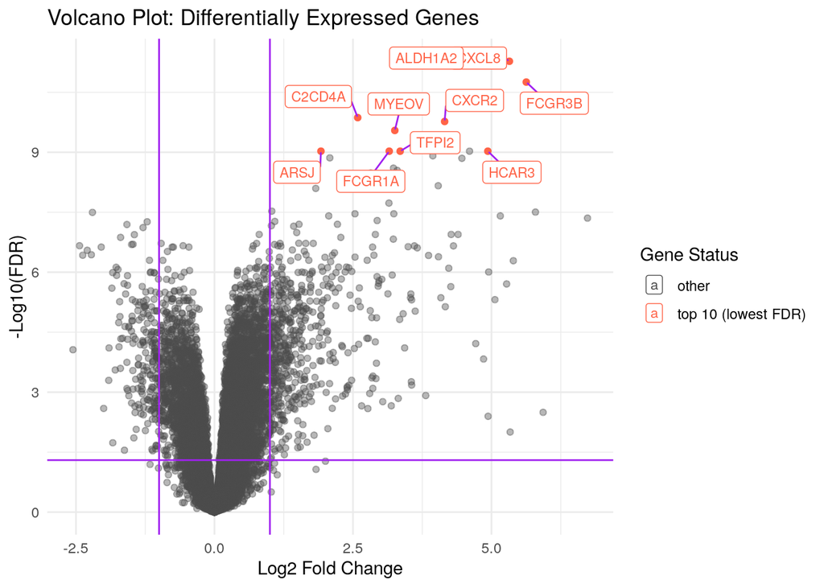

*Figure 2: Volcano plot displaying the statistical significance (FDR) and log fold change (logFC) of differentially expressed genes. Each point represents a gene, with the x-axis indicating log2 fold change and the y-axis showing the -log10 transformed FDR. The top 10 most statistically significant genes (lowest FDR) are highlighted in red and labeled. Vertical purple lines represent a fold change threshold of ±1 (log2 scale), and the horizontal purple line indicates an FDR threshold of 0.05. This visualization helps identify key differentially expressed genes with high statistical significance and large expression changes.*

```r
# We highlight the top 10 genes (lowest FDR)
# and label them with their rownames (gene symbols).

# Make a copy of the DE table for plotting
volcano_data <- DE_table

# Sort by FDR so the top 10 are in the first rows
volcano_data <- volcano_data[order(volcano_data$FDR), ]
# Ensure there's no confusion about ordering:
volcano_data$status <- "other"
volcano_data$status[1:10] <- "top 10 (lowest FDR)"

point_palette <- c("gray30", "tomato")
names(point_palette) <- c("other", "top 10 (lowest FDR)")

# Create a new column for text labels
volcano_data$text_label <- NA
volcano_data$text_label[1:10] <- rownames(volcano_data)[1:10]

# Build the volcano plot
volcano_plot <- ggplot(data = volcano_data,
                       aes(x = logFC,
                           y = -log10(FDR),
                           color = status)) +
  # Plot non-top-10 genes first (background)
  geom_point(data = subset(volcano_data, status == "other"),
             alpha = 0.4) +
  # Plot vertical lines indicating |logFC| = 1
  geom_vline(xintercept = c(-1, 1), color = "purple") +
  # Plot horizontal line indicating FDR = 0.05
  geom_hline(yintercept = -log10(0.05), color = "purple") +
  # Plot the top-10 genes (foreground)
  geom_point(data = subset(volcano_data, status == "top 10 (lowest FDR)")) +
  theme_minimal() +
  scale_color_manual("Gene Status", values = point_palette) +
  # Label the top 10 genes
  geom_label_repel(aes(label = text_label),
                   box.padding       = 0.35,
                   segment.color     = 'purple',
                   min.segment.length = 0,
                   max.overlaps      = 30,
                   size              = 3) +
  # ylim(c(-1, 10)) +  # Limits vertical
  xlab("Log2 Fold Change") +
  ylab("-Log10(FDR)") +
  ggtitle("Volcano Plot: Differentially Expressed Genes")

volcano_plot
```

From the purple lines indicating the FDR and log fold change thresholds, many genes pass both thresholds. This is not unexpected given how many passed the earlier p-value and log fold change thresholds from earlier. Since the top 10 lowest FDR genes have a positive log fold change, it seems that the most statistically significant genes are upregulated. This is confirmed by the output of the code below.

```r
# Top 10 upregulated (highest positive logFC, lowest FDR)
top10_upregulated <- volcano_data[order(-volcano_data$logFC, volcano_data$FDR), ][1:10, ]

# Top 10 downregulated (highest negative logFC, lowest FDR)
top10_downregulated <- volcano_data[order(volcano_data$logFC, volcano_data$FDR), ][1:10, ]

head(top10_upregulated)
```

```
##           logFC   logCPM         F       PValue          FDR
## MMP3   6.732809 6.180051  62.99635 8.119178e-11 4.440649e-08
## MUC5AC 5.931002 2.712175  15.53415 6.784867e-04 3.197188e-03
## AQP9   5.793250 3.597733  70.72997 4.586001e-11 3.135296e-08
## FCGR3B 5.627481 4.685126 102.21343 3.211478e-15 1.756464e-11
## CXCL5  5.394049 5.753737  54.26681 2.994181e-09 5.157255e-07
## BPIFB1 5.336768 2.300242  11.34871 2.799242e-03 9.928658e-03
##                     status text_label
## MMP3                 other       <NA>
## MUC5AC               other       <NA>
## AQP9                 other       <NA>
## FCGR3B top 10 (lowest FDR)     FCGR3B
## CXCL5                other       <NA>
## BPIFB1               other       <NA>
```

```r
head(top10_downregulated)
```

```
##            logFC   logCPM        F       PValue          FDR status text_label
## REG3G  -2.554091 3.697660 26.93282 5.507558e-06 8.674848e-05  other       <NA>
## CNTFR  -2.435632 3.821306 62.61268 7.847612e-10 2.176561e-07  other       <NA>
## CDHR1  -2.378107 7.151972 58.66271 1.891253e-09 3.756081e-07  other       <NA>
## FAM25C -2.296094 1.672488 52.58582 1.275266e-09 2.827645e-07  other       <NA>
## LRAT   -2.222716 4.247581 59.51144 1.759162e-09 3.653712e-07  other       <NA>
## FRMD1  -2.202999 4.842597 78.28837 4.858666e-11 3.188839e-08  other       <NA>
```

Regarding associations with the stomach, multiple of the top 10 genes have been associated with Crohn’s disease or inflammation (which is often associated with Crohn’s disease). These gene as well as justification for their relationship to Crohn’s disease are noted below.

- CXCL8: The gene has been noted, “as a Potential Biomarker for Crohn’s Disease is Associated with Immune Infiltration and RNA Methylation” [8].
- CXCR2: As the receptor for CXCL8, CXCR2 mediates neutrophil chemotaxis. The CXCL8-CXCR2 axis is integral to the inflammatory response in CD, with studies indicating that its dysregulation contributes to disease pathogenesis [9].
- FCGR3B (CD16b): Expressed on neutrophils, this receptor binds the Fc region of IgG antibodies, facilitating the clearance of immune complexes and modulating inflammatory responses [10].
- FCGR1A (CD64): IL-23, a pro-inflammatory cytokine, contributes to IBD pathogenesis, with FcγRI (CD64)-expressing myeloid cells as its primary source in inflamed gut tissue and high CD64 expression is associated with Mucosal Inflammation in Pediatric Crohn’s Disease [11, 12].
- ALDH1A2: an enzyme involved in retinoic acid (RA) synthesis, plays a role in Crohn’s disease (CD) and other inflammatory bowel diseases (IBD) by influencing gut immunity and inflammation, with ALDH1A2 expression potentially being upregulated in inflamed IBD colonic mucosa [13].

## Differentially Expressed Genes in The Source study

The source study used kallisto for pseudoalignment and TPM-based quantification, filtering genes with ≥1 TPM in at least 20% of samples, whereas I used raw counts from GEO and applied an edgeR pipeline, filtering genes with ≥1 CPM in at least 4 samples (using the methodology from class)[1, 3]. Their analysis proceeded with log-transformed TPM values and Weighted Gene Co-Expression Network Analysis (WGCNA) to identify modules of co-expressed genes, while I conducted single-gene differential expression analysis using edgeR’s quasi-likelihood framework. Additionally, their approach did not involve TMM normalization, as TPM values already adjust for library size, whereas I performed TMM normalization before differential expression analysis [1].

Their main differential expression (DE) readout is fundamentally different from mine as of now. Instead of identifying individual differentially expressed genes with fold-change and adjusted p-values (as in a traditional volcano plot), they focused on WGCNA modules—clusters of genes with similar expression patterns—and assessed their correlation with Crohn’s disease (CD), diet, microbiome, and metabolomics [1]. While I generated a ranked list of significantly up- and down-regulated genes, their study highlights biologically meaningful gene sets, such as immune-inflammatory pathways (CXCL8, TREM1) and metabolic downregulation in CD, without explicitly listing all significant DE genes [1]. This systems-level approach emphasizes pathway-level effects rather than individual gene changes, making direct comparisons to my single-gene DE results somewhat incommensurable.

Despite this, there is overalp between the gene sets output by the paper and the top 10 genes noted by the volcano plot analysis above. CXCL8 is noted as one of the immune system related extracellular matrix genes which are upregulated in Crohn’s disease [1]. Considering the lack of overlap between the methodologies, and that we are comparing only a sample of genes from each analysis, this is fairly promising. There is no overlap between the top 10 most downregulated genes in Crohn’s with the top 10 most significantly downregulated genes in the volcano plot above.

## Heat Map

To see how the conditions cluster more formally, lets make a heat map from the final normalized counts. Repurposing the code from class, we can produce the following heat map[3].

```r
# Make a copy of the normalized data
my_heatmap_matrix <- final_normalized_counts

sig_gene_names <- rownames(DE_significant)

# Create the heat map matrix by finding the DE genes, transposing to scale the row by subtracting by mean and dividing by SD then transposing back
my_heatmap_matrix_sigonly <- t(
  scale(
    t(my_heatmap_matrix[rownames(my_heatmap_matrix) %in% sig_gene_names, ])
  )
)

heatmap_colors <- colorRamp2(
  c(min(my_heatmap_matrix_sigonly), 0, max(my_heatmap_matrix_sigonly)),
  c("purple", "white", "orange")
)

# factor of interest is 'diagnosis' with levels: "Control", "CD".
diagnosis_palette <- c("Control" = "lightblue",
                       "CD"      = "pink")

sample_annotation <- HeatmapAnnotation(
  df = data.frame(Diagnosis = sample_metadata$diagnosis),
  col = list(Diagnosis = diagnosis_palette),
  show_legend = TRUE
)

my_heatmap <- Heatmap(
  as.matrix(my_heatmap_matrix_sigonly),
  name              = "Relative Expression",
  top_annotation    = sample_annotation,
  cluster_rows      = TRUE,   # cluster by gene
  cluster_columns   = TRUE,   # cluster by sample
  show_row_dend     = TRUE,
  show_column_dend  = TRUE,
  col               = heatmap_colors,
  show_row_names    = FALSE,  # hide row names for clarity
  show_column_names = FALSE,  # hide column names for clarity
  row_title         = "Genes",
  column_title      = "Heatmap of DE Genes (FDR < 0.05)"
)
```

```
## `use_raster` is automatically set to TRUE for a matrix with more than
## 2000 rows. You can control `use_raster` argument by explicitly setting
## TRUE/FALSE to it.
##
## Set `ht_opt$message = FALSE` to turn off this message.
```

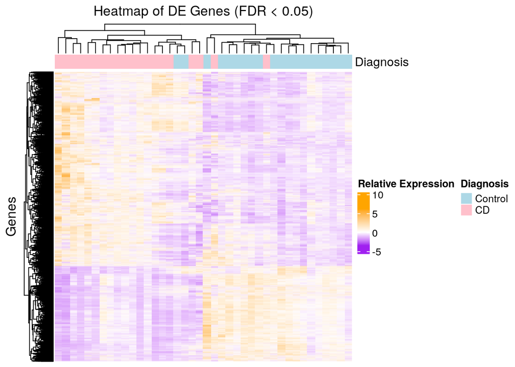

*Figure 3: Heatmap of differentially expressed (DE) genes in Crohn’s disease (CD) vs. control samples. Expression values are TMM-normalized and scaled by row. Each row represents a gene, and each column represents a sample. Colors indicate relative expression levels, with purple representing downregulation, white indicating no change, and orange representing upregulation. Samples are hierarchically clustered based on expression similarity. The top annotation bar indicates sample diagnosis: light blue for controls and pink for CD samples.*

```r
my_heatmap
```

# Over Representation Analysis (ORA)

Over-representation analysis is a statistical method used to determine whether a predefined set of genes (e.g., from a biological pathway) is significantly enriched among differentially expressed genes, helping identify relevant biological processes or functions associated with the dataset [3]. We will be doing ORA on our differentially expressed genes to find up and down regulated gene sets.

## ORA Methods

I have chosen to use `gprofiler2` for ORA because they contain gene sets with the latest annotations and is the recommendation in lecture 8 [3]. This is especially important for gene sets because older sets might not contain pathway information of newer sets or may even contain outdated, falsified information [14].

Since the focus of this analysis is on Crohn’s disease and irritable bowel syndrome (IBS), the best annotation sources would be those that provide disease-related pathways, immune response mechanisms, and gut-related biological processes. I chose not to query all the available sources, since that resulted in a cluttered output.

Instead, I decided on the gene set from Kyoto Encyclopedia of Genes and Genomes (KEGG). This is the dataset I did my homework analysis on a few weeks ago. The homework lead to my discovery that KEGG has a pathway specifically for inflammatory bowel disease, an affliction people with Crohn’s disease are often diagnosed with [1, 15]. In their notes, they reference Crohn’s disease as one of the afflictions which files under this umbrella term along with irritable bowel syndrome [15]. Additionally, the provide a curated disease-related pathways, immune response mechanisms, and phenotype associations relevant to Crohn’s disease and irritable bowel syndrome [15].The KEGG PATHWAYS gene sets accessed through `gprofiler2` contains the 2024-01-22 version of the KEGG gene set.

## Gene Set Queries

To use either the web based version of gprofiler or the R package, we first define sets for all the upregulated, downregulated, and all differentially expressed genes based on FDR. Following the procedure from earlier, upregulation is noted by a log fold change greater than 0 while downregulation is change less than 0 [3]. The code below is a modified version from class [3].

```r
# Genes with a log fold change above 0 (Upregulated in Crohn's disease)
ora_up_genes <- rownames(my_DE_results)[
  my_DE_results$FDR < 0.05 & my_DE_results$logFC > 0
]

# Genes with a log fold change below 0 (Downregulated in Crohn's disease)
ora_down_genes<- rownames(my_DE_results)[
  my_DE_results$FDR < 0.05 & my_DE_results$logFC < 0
]

# All significantly differentially expressed (DE) genes (FDR cutoff only)
ora_all_genes <- rownames(my_DE_results)[
  my_DE_results$FDR < 0.05
]

# Write upregulated genes to a text file
write.table(
  x = ora_up_genes,
  file = file.path(getwd(), "CD_upregulated_genes.txt"),
  col.names = FALSE,
  quote = FALSE,
  row.names=FALSE
)

# Write downregulated genes to a text file
write.table(
  x = ora_down_genes,
  file = file.path(getwd(), "CD_downregulated_genes.txt"),
  col.names = FALSE,
  quote = FALSE,
  row.names=FALSE
)

# Write all significant DE genes to a text file
write.table(
  x = ora_all_genes,
  file = file.path(getwd(), "CD_significant_genes.txt"),
  col.names = FALSE,
  quote = FALSE
  ,row.names=FALSE
)

# Print summary
cat("Number of upregulated genes:", length(ora_up_genes), "\n")
```

```
## Number of upregulated genes: 4608
```

```r
cat("Number of downregulated genes:", length(ora_down_genes), "\n")
```

```
## Number of downregulated genes: 2278
```

```r
cat("Total number of significant DE genes:", length(ora_all_genes), "\n")
```

```
## Total number of significant DE genes: 6886
```

I saved the genes in a txt file to compare the results of the web based version of g:Profiler to that output by code below. More on this in the journal.

```r
# Upregulated Genes
gprofiler_up <- gost(
  query              = ora_up_genes,
  organism           = "hsapiens",
  user_threshold     = 0.05,
  correction_method  = "fdr",
  sources            = c("KEGG"), # , "REAC", "HP", "WP"
  significant        = TRUE
)

# Downregulated Genes
gprofiler_down <- gost(
  query              = ora_down_genes,
  organism           = "hsapiens",
  user_threshold     = 0.05,
  correction_method  = "fdr",
  sources            = c("KEGG"), # , "REAC", "HP", "WP",
  significant        = TRUE
)

# All Significant Genes
gprofiler_all <- gost(
  query              = ora_all_genes,
  organism           = "hsapiens",
  user_threshold     = 0.05,
  correction_method  = "fdr",
  sources          = c("KEGG"), # , "REAC", "HP", "WP"
  significant        = TRUE
)

# Printing Summaries
cat("Number of KEGG terms enriched (Up):",
    if(is.null(gprofiler_up)) 0 else nrow(gprofiler_up$result), "\n")
```

```
## Number of KEGG terms enriched (Up): 77
```

```r
cat("Number of KEGG terms enriched (Down):",
    if(is.null(gprofiler_down)) 0 else nrow(gprofiler_down$result), "\n")
```

```
## Number of KEGG terms enriched (Down): 29
```

```r
cat("Number of KEGG terms enriched (All DE Genes):",
    if(is.null(gprofiler_all)) 0 else nrow(gprofiler_all$result), "\n")
```

```
## Number of KEGG terms enriched (All DE Genes): 42
```

The number of upregulated KEGG terms returned is greater than the number of terms from the down regulated and all differentially expressed genes combined. Some pathways may be strongly enriched in only upregulated genes but not in downregulated genes, or vice versa. When both sets are combined, pathways that were significant in separate lists might lose statistical significance because the signal is diluted [16].

Before analyzing the ORA results, lets define a function to clean and format the `gprofiler2` results into a table.

```r
# Function to clean and format g:Profiler results for a table
format_gprofiler_results <- function(gprofiler_results) {
  if (is.null(gprofiler_results$result)) {
    return(data.frame(Message = "No significant pathways found"))
  }

  # Convert to dataframe and remove unnecessary columns
  df <- as.data.frame(gprofiler_results$result) %>%
    select(-query, -query_size, -recall, -significant, -effective_domain_size, -source_order, -parents)

  return(df)
}
```

Note that the following ORA result tables are clipped to only include up to the last relevant entry to reduce clutter.

## Upregulated ORA Results

```r
# Format upregulated results
formatted_up <- format_gprofiler_results(gprofiler_up) %>% head(68)
kable(formatted_up, format = "html", caption = "Table 2: Over-representation analysis results for **upregulated** genes in CD samples.") %>%
  kable_styling(bootstrap_options = "striped", full_width = FALSE) %>%
  scroll_box(height = "400px")
```

Table 2: Over-representation analysis results for **upregulated** genes in CD samples.

| p_value | term_size | intersection_size | precision | term_id | source | term_name |
| --- | --- | --- | --- | --- | --- | --- |
| 0.0000000 | 168 | 89 | 0.0404914 | KEGG:04141 | KEGG | Protein processing in endoplasmic reticulum |
| 0.0000000 | 46 | 36 | 0.0163785 | KEGG:03050 | KEGG | Proteasome |
| 0.0000000 | 76 | 48 | 0.0218380 | KEGG:05133 | KEGG | Pertussis |
| 0.0000000 | 157 | 78 | 0.0354868 | KEGG:04110 | KEGG | Cell cycle |
| 0.0000000 | 147 | 73 | 0.0332120 | KEGG:04145 | KEGG | Phagosome |
| 0.0000000 | 88 | 50 | 0.0227480 | KEGG:05323 | KEGG | Rheumatoid arthritis |
| 0.0000002 | 198 | 89 | 0.0404914 | KEGG:05169 | KEGG | Epstein-Barr virus infection |
| 0.0000008 | 218 | 94 | 0.0427662 | KEGG:05166 | KEGG | Human T-cell leukemia virus 1 infection |
| 0.0000031 | 72 | 40 | 0.0181984 | KEGG:05140 | KEGG | Leishmaniasis |
| 0.0000060 | 49 | 30 | 0.0136488 | KEGG:05144 | KEGG | Malaria |
| 0.0000060 | 31 | 22 | 0.0100091 | KEGG:03060 | KEGG | Protein export |
| 0.0000198 | 56 | 32 | 0.0145587 | KEGG:05134 | KEGG | Legionellosis |
| 0.0000199 | 74 | 39 | 0.0177434 | KEGG:04115 | KEGG | p53 signaling pathway |
| 0.0000201 | 249 | 99 | 0.0450409 | KEGG:05132 | KEGG | Salmonella infection |
| 0.0000201 | 167 | 72 | 0.0327571 | KEGG:05164 | KEGG | Influenza A |
| 0.0000236 | 113 | 53 | 0.0241128 | KEGG:04668 | KEGG | TNF signaling pathway |
| 0.0000409 | 132 | 59 | 0.0268426 | KEGG:04380 | KEGG | Osteoclast differentiation |
| 0.0000775 | 155 | 66 | 0.0300273 | KEGG:04218 | KEGG | Cellular senescence |
| 0.0000977 | 40 | 24 | 0.0109190 | KEGG:04940 | KEGG | Type I diabetes mellitus |
| 0.0001091 | 63 | 33 | 0.0150136 | KEGG:05416 | KEGG | Viral myocarditis |
| 0.0001231 | 53 | 29 | 0.0131938 | KEGG:00510 | KEGG | N-Glycan biosynthesis |
| 0.0001953 | 92 | 43 | 0.0195632 | KEGG:04657 | KEGG | IL-17 signaling pathway |
| 0.0002048 | 175 | 71 | 0.0323021 | KEGG:05152 | KEGG | Tuberculosis |
| 0.0003080 | 108 | 48 | 0.0218380 | KEGG:05145 | KEGG | Toxoplasmosis |
| 0.0003208 | 162 | 66 | 0.0300273 | KEGG:05161 | KEGG | Hepatitis B |
| 0.0003247 | 138 | 58 | 0.0263876 | KEGG:05162 | KEGG | Measles |
| 0.0003584 | 106 | 47 | 0.0213831 | KEGG:04620 | KEGG | Toll-like receptor signaling pathway |
| 0.0004252 | 98 | 44 | 0.0200182 | KEGG:04061 | KEGG | Viral protein interaction with cytokine and cytokine receptor |
| 0.0004459 | 214 | 82 | 0.0373066 | KEGG:05417 | KEGG | Lipid and atherosclerosis |
| 0.0005324 | 231 | 87 | 0.0395814 | KEGG:05171 | KEGG | Coronavirus disease - COVID-19 |
| 0.0005345 | 44 | 24 | 0.0109190 | KEGG:00970 | KEGG | Aminoacyl-tRNA biosynthesis |
| 0.0005345 | 34 | 20 | 0.0090992 | KEGG:05330 | KEGG | Allograft rejection |
| 0.0006015 | 363 | 127 | 0.0577798 | KEGG:05014 | KEGG | Amyotrophic lateral sclerosis |
| 0.0006282 | 223 | 84 | 0.0382166 | KEGG:05163 | KEGG | Human cytomegalovirus infection |
| 0.0007032 | 69 | 33 | 0.0150136 | KEGG:04612 | KEGG | Antigen processing and presentation |
| 0.0008025 | 101 | 44 | 0.0200182 | KEGG:05142 | KEGG | Chagas disease |
| 0.0009727 | 21 | 14 | 0.0063694 | KEGG:00532 | KEGG | Glycosaminoglycan biosynthesis - chondroitin sulfate / dermatan sulfate |
| 0.0016076 | 194 | 73 | 0.0332120 | KEGG:05167 | KEGG | Kaposi sarcoma-associated herpesvirus infection |
| 0.0016076 | 265 | 95 | 0.0432211 | KEGG:05012 | KEGG | Parkinson disease |
| 0.0016076 | 210 | 78 | 0.0354868 | KEGG:05170 | KEGG | Human immunodeficiency virus 1 infection |
| 0.0016076 | 104 | 44 | 0.0200182 | KEGG:04625 | KEGG | C-type lectin receptor signaling pathway |
| 0.0017500 | 201 | 75 | 0.0341219 | KEGG:05203 | KEGG | Viral carcinogenesis |
| 0.0019782 | 37 | 20 | 0.0090992 | KEGG:05332 | KEGG | Graft-versus-host disease |
| 0.0024438 | 100 | 42 | 0.0191083 | KEGG:04933 | KEGG | AGE-RAGE signaling pathway in diabetic complications |
| 0.0024438 | 62 | 29 | 0.0131938 | KEGG:05321 | KEGG | Inflammatory bowel disease |
| 0.0030827 | 101 | 42 | 0.0191083 | KEGG:05146 | KEGG | Amoebiasis |
| 0.0032067 | 49 | 24 | 0.0109190 | KEGG:00520 | KEGG | Amino sugar and nucleotide sugar metabolism |
| 0.0045712 | 50 | 24 | 0.0109190 | KEGG:05110 | KEGG | Vibrio cholerae infection |
| 0.0045845 | 82 | 35 | 0.0159236 | KEGG:04623 | KEGG | Cytosolic DNA-sensing pathway |
| 0.0045845 | 271 | 94 | 0.0427662 | KEGG:05020 | KEGG | Prion disease |
| 0.0045845 | 291 | 100 | 0.0454959 | KEGG:04060 | KEGG | Cytokine-cytokine receptor interaction |
| 0.0045845 | 42 | 21 | 0.0095541 | KEGG:00513 | KEGG | Various types of N-glycan biosynthesis |
| 0.0045845 | 76 | 33 | 0.0150136 | KEGG:05220 | KEGG | Chronic myeloid leukemia |
| 0.0045845 | 153 | 58 | 0.0263876 | KEGG:03010 | KEGG | Ribosome |
| 0.0051496 | 37 | 19 | 0.0086442 | KEGG:01250 | KEGG | Biosynthesis of nucleotide sugars |
| 0.0058493 | 158 | 59 | 0.0268426 | KEGG:05160 | KEGG | Hepatitis C |
| 0.0070782 | 305 | 103 | 0.0468608 | KEGG:05016 | KEGG | Huntington disease |
| 0.0071492 | 182 | 66 | 0.0300273 | KEGG:04621 | KEGG | NOD-like receptor signaling pathway |
| 0.0084254 | 382 | 125 | 0.0568699 | KEGG:05010 | KEGG | Alzheimer disease |
| 0.0093189 | 197 | 70 | 0.0318471 | KEGG:05130 | KEGG | Pathogenic Escherichia coli infection |
| 0.0094395 | 36 | 18 | 0.0081893 | KEGG:03030 | KEGG | DNA replication |
| 0.0105606 | 86 | 35 | 0.0159236 | KEGG:05150 | KEGG | Staphylococcus aureus infection |
| 0.0116153 | 140 | 52 | 0.0236579 | KEGG:04120 | KEGG | Ubiquitin mediated proteolysis |
| 0.0135166 | 190 | 67 | 0.0304823 | KEGG:04062 | KEGG | Chemokine signaling pathway |
| 0.0169968 | 136 | 50 | 0.0227480 | KEGG:05135 | KEGG | Yersinia infection |
| 0.0169968 | 70 | 29 | 0.0131938 | KEGG:05120 | KEGG | Epithelial cell signaling in Helicobacter pylori infection |
| 0.0169968 | 474 | 149 | 0.0677889 | KEGG:05022 | KEGG | Pathways of neurodegeneration - multiple diseases |
| 0.0191910 | 108 | 41 | 0.0186533 | KEGG:03013 | KEGG | Nucleocytoplasmic transport |

Within these upregulated genes (i.e., genes having FDR < 0.05 and logFC > 0), multiple enriched pathways involve immune activation and inflammatory signaling, which is consistent with known pathophysiological mechanisms in Crohn’s disease (CD). Several pathways stand out, many of which are fairly highly ranked among the 77 pathways ordered by p-value. Note that the order for the adjusted p-value on the g:Profiler website mirrors that of the output here.

Inflammatory Bowel Disease (p=0.0024438) | Rank 45: This pathway specifically mentions Crohn’s disease and ulcerative colitis [15]. Its enrichment in upregulated genes aligns well with the chronic inflammatory nature of CD.

TNF Signaling Pathway (p=0.0000236) | Rank 16: TNF-α is a key cytokine strongly implicated in CD, and anti-TNF therapies (e.g., infliximab) are a mainstay of CD treatment [19]. IL-17 Signaling Pathway (p=0.0001953): IL-17 is produced by Th17 cells, which also play a significant role in mucosal inflammation and epithelial barrier regulation in the gut.

Rheumatoid Arthritis (p=0.0000000) | Rank 6: While not directly a GI disease, RA is autoimmune in nature, and its enrichment highlights shared inflammatory circuits (e.g., TNF, IL-17) typical of autoimmune disorders [20].

## Downregulated ORA Results

```r
# Format downregulated results
formatted_down <- format_gprofiler_results(gprofiler_down)
kable(formatted_down, format = "html", caption = "Table 3: Over-representation analysis results for **downregulated** genes in CD samples.") %>%
  kable_styling(bootstrap_options = "striped", full_width = FALSE) %>%
  scroll_box(height = "400px")
```

Table 3: Over-representation analysis results for **downregulated** genes in CD samples.

| p_value | term_size | intersection_size | precision | term_id | source | term_name |
| --- | --- | --- | --- | --- | --- | --- |
| 0.0000000 | 1537 | 274 | 0.2927350 | KEGG:01100 | KEGG | Metabolic pathways |
| 0.0000084 | 67 | 24 | 0.0256410 | KEGG:05204 | KEGG | Chemical carcinogenesis - DNA adducts |
| 0.0000084 | 68 | 24 | 0.0256410 | KEGG:00982 | KEGG | Drug metabolism - cytochrome P450 |
| 0.0000084 | 68 | 24 | 0.0256410 | KEGG:00830 | KEGG | Retinol metabolism |
| 0.0000541 | 75 | 24 | 0.0256410 | KEGG:03320 | KEGG | PPAR signaling pathway |
| 0.0000772 | 62 | 21 | 0.0224359 | KEGG:00140 | KEGG | Steroid hormone biosynthesis |
| 0.0001011 | 24 | 12 | 0.0128205 | KEGG:04977 | KEGG | Vitamin digestion and absorption |
| 0.0001011 | 74 | 23 | 0.0245726 | KEGG:00980 | KEGG | Metabolism of xenobiotics by cytochrome P450 |
| 0.0002299 | 89 | 25 | 0.0267094 | KEGG:04976 | KEGG | Bile secretion |
| 0.0002299 | 43 | 16 | 0.0170940 | KEGG:04975 | KEGG | Fat digestion and absorption |
| 0.0004019 | 36 | 14 | 0.0149573 | KEGG:00040 | KEGG | Pentose and glucuronate interconversions |
| 0.0004489 | 99 | 26 | 0.0277778 | KEGG:00564 | KEGG | Glycerophospholipid metabolism |
| 0.0004489 | 61 | 19 | 0.0202991 | KEGG:00590 | KEGG | Arachidonic acid metabolism |
| 0.0020092 | 120 | 28 | 0.0299145 | KEGG:04152 | KEGG | AMPK signaling pathway |
| 0.0042841 | 83 | 21 | 0.0224359 | KEGG:04146 | KEGG | Peroxisome |
| 0.0043754 | 30 | 11 | 0.0117521 | KEGG:00053 | KEGG | Ascorbate and aldarate metabolism |
| 0.0053257 | 103 | 24 | 0.0256410 | KEGG:04974 | KEGG | Protein digestion and absorption |
| 0.0063053 | 63 | 17 | 0.0181624 | KEGG:00561 | KEGG | Glycerolipid metabolism |
| 0.0100405 | 108 | 24 | 0.0256410 | KEGG:04931 | KEGG | Insulin resistance |
| 0.0125733 | 79 | 19 | 0.0202991 | KEGG:00983 | KEGG | Drug metabolism - other enzymes |
| 0.0125733 | 45 | 13 | 0.0138889 | KEGG:02010 | KEGG | ABC transporters |
| 0.0125733 | 170 | 33 | 0.0352564 | KEGG:04530 | KEGG | Tight junction |
| 0.0246401 | 60 | 15 | 0.0160256 | KEGG:04978 | KEGG | Mineral absorption |
| 0.0246401 | 6 | 4 | 0.0042735 | KEGG:00440 | KEGG | Phosphonate and phosphinate metabolism |
| 0.0246401 | 43 | 12 | 0.0128205 | KEGG:00071 | KEGG | Fatty acid degradation |
| 0.0347693 | 211 | 37 | 0.0395299 | KEGG:05207 | KEGG | Chemical carcinogenesis - receptor activation |
| 0.0347693 | 34 | 10 | 0.0106838 | KEGG:04710 | KEGG | Circadian rhythm |
| 0.0400646 | 70 | 16 | 0.0170940 | KEGG:04920 | KEGG | Adipocytokine signaling pathway |
| 0.0402319 | 58 | 14 | 0.0149573 | KEGG:04923 | KEGG | Regulation of lipolysis in adipocytes |

When examining the downregulated genes (logFC < 0, FDR < 0.05), we see a strong emphasis on metabolic and digestive pathways, which may hint at diminished absorptive or nutrient-processing capacity in Crohn’s disease [21, 22]. Several key pathways stand out as potentially relevant to gut health and inflammatory processes. The ones among the top 10 are highlighted here.

Additionally,with regards to the pathway Tight Junction (p=0.0125733), Tight junction proteins regulate intestinal barrier integrity. Downregulation here may exacerbate intestinal permeability (“leaky gut”), and “patients with clinically active CD have increased intestinal permeability” [23].

There are other potentially relevant pathways as well; however, this is more than enough to be considered promising for now. More to be examined later.

## All Genes ORA Results

```r
# Format all significant results
formatted_all <- format_gprofiler_results(gprofiler_all) %>% head(20)
kable(formatted_all, format = "html", caption = "Table 4: Over-representation analysis results for **all significant** genes in CD samples.") %>%
  kable_styling(bootstrap_options = "striped", full_width = FALSE) %>%
  scroll_box(height = "400px")
```

Table 4: Over-representation analysis results for **all significant** genes in CD samples.

| p_value | term_size | intersection_size | precision | term_id | source | term_name |
| --- | --- | --- | --- | --- | --- | --- |
| 0.0000000 | 1537 | 687 | 0.2192087 | KEGG:01100 | KEGG | Metabolic pathways |
| 0.0000008 | 168 | 99 | 0.0315890 | KEGG:04141 | KEGG | Protein processing in endoplasmic reticulum |
| 0.0000014 | 46 | 36 | 0.0114869 | KEGG:03050 | KEGG | Proteasome |
| 0.0000117 | 157 | 90 | 0.0287173 | KEGG:04110 | KEGG | Cell cycle |
| 0.0000202 | 76 | 50 | 0.0159541 | KEGG:05133 | KEGG | Pertussis |
| 0.0002958 | 31 | 24 | 0.0076579 | KEGG:03060 | KEGG | Protein export |
| 0.0009337 | 88 | 52 | 0.0165922 | KEGG:05323 | KEGG | Rheumatoid arthritis |
| 0.0009474 | 147 | 79 | 0.0252074 | KEGG:04145 | KEGG | Phagosome |
| 0.0020013 | 53 | 34 | 0.0108488 | KEGG:00510 | KEGG | N-Glycan biosynthesis |
| 0.0030965 | 56 | 35 | 0.0111678 | KEGG:05134 | KEGG | Legionellosis |
| 0.0044742 | 218 | 107 | 0.0341417 | KEGG:05166 | KEGG | Human T-cell leukemia virus 1 infection |
| 0.0046993 | 49 | 31 | 0.0098915 | KEGG:05144 | KEGG | Malaria |
| 0.0073252 | 214 | 104 | 0.0331844 | KEGG:05417 | KEGG | Lipid and atherosclerosis |
| 0.0073252 | 21 | 16 | 0.0051053 | KEGG:00532 | KEGG | Glycosaminoglycan biosynthesis - chondroitin sulfate / dermatan sulfate |
| 0.0092964 | 74 | 42 | 0.0134014 | KEGG:04115 | KEGG | p53 signaling pathway |
| 0.0112637 | 41 | 26 | 0.0082961 | KEGG:04216 | KEGG | Ferroptosis |
| 0.0128935 | 113 | 59 | 0.0188258 | KEGG:04668 | KEGG | TNF signaling pathway |
| 0.0166076 | 44 | 27 | 0.0086152 | KEGG:00970 | KEGG | Aminoacyl-tRNA biosynthesis |
| 0.0178852 | 72 | 40 | 0.0127632 | KEGG:05140 | KEGG | Leishmaniasis |
| 0.0215635 | 155 | 76 | 0.0242502 | KEGG:04218 | KEGG | Cellular senescence |

### Overlap of Table 4 with Table 2 (Upregulated)

Likewise, many of the immune and inflammatory pathways from Table 2, such as TNF signaling, Phagosome, and Protein processing in the endoplasmic reticulum, re-emerge in Table 4. These pathways are major contributors to pro-inflammatory states in the gut and, when viewed in combination with downregulated metabolic processes, provide a more holistic picture of Crohn’s disease pathology—heightened immune activity alongside disturbed nutrient handling. Because Table 4 includes both up- and downregulated genes, it incorporates these immune-driven disruptions from Table 2 plus the metabolic deficits from Table 3.

## Comparing ORA Results to Data Source Paper

The original source paper aimed to investigate environmental exposures, dietary patterns, ileal transcriptomic profiles, metabolomic data, and the microbiome in newly diagnosed Crohn’s disease patients and healthy controls from both rural and urban regions of China and Israel [1].

As noted in the section `Differentially Expressed Genes in The Source study`, their methodology was seemingly incommeasureable with regards to differential expression analysis; however, their ORA outcomes map fairly directly to many of the enriched pathways in both Table 2 and Table 3. More details on how they achieved their ORA results in the `Differentially Expressed Genes in The Source study`.

### Upregulated Genes (Table 2) vs. “Up in Crohn” Modules

Many of the pathways enriched in Table 2 (e.g., TNF signaling, Toll-like receptor signaling, IL-17 signaling, and Phagosome) map well onto the “Up in Crohn” category in the paper where the authors noted the enriched pathways they found in Crohn’s disease [1].

The most relevant enriched pathways from the paper are noted below with an explanation of how they relate to pathways found in Table 2.

Immune ECM / Myeloid module: The strong representation of pro-inflammatory pathways (TNF, TLR, IL-17) suggests heightened myeloid cell involvement and immune extracellular matrix remodeling—consistent with active inflammation [1, 20].

Epithelial defense: Enhanced epithelial-associated pathways (e.g., Cell cycle, Phagosome) reflect an upregulated protective response at the mucosal surface, aligning with the figure’s emphasis on epithelial defense [1, 17, 18].

T/B Cells: Several immune-centric pathways in Table 2 relate to lymphocyte activation (e.g., antigen processing/presentation) [18].

### Downregulated Genes (Table 3) vs. “Down in Crohn” Modules

The “Down in Crohn” pathways of energy metabolism, lipid digestion, and mitochondrial structure in the source paper align well with the reduced metabolic capacity reflected in Table 3.

The most relevant enriched pathways from the paper are noted below with an explanation of how they relate to pathways found in Table 3.

Lipid Metabolism / Mitochondrial Structure: Pathways such as Bile secretion, Fat digestion and absorption, Arachidonic acid metabolism indicate suppressed lipid handling, resonating with “Lipid Metabolism” and “Respiration ATP” (i.e., mitochondrial dysfunction) in the source paper.

Respiration / ATP Production: The downregulation of pathways crucial for nutrient absorption and energy homeostasis (e.g., vitamin digestion, peroxisome activity) suggests broad deficits in cellular respiration, paralleling “Respiration ATP” from the figure [22].

# Conclusion

The results demonstrate a significant upregulation of inflammatory bowel disease pathways, particularly those associated with Crohn’s disease. Many pathways directly related to Crohn’s disease were identified among both upregulated and downregulated genes, reinforcing the robustness of the dataset in capturing disease-associated transcriptional changes. This suggests that the clinical RNA-seq data effectively reflects the molecular impact of Crohn’s disease. Given that all samples were derived from individuals with and without the disease under well-controlled conditions, and the study employed rigorous RNA extraction and sequencing protocols [1], these findings are unlikely to be artifacts of poor sample handling. The high-quality sample preparation and sequencing methods further support the reliability of these observed transcriptional differences.

# References

Credits to GitHub Copilot for code completions and comment assistance.

1. Braun T, Feng R, Amir A, Levhar N, Shacham H, Mao R, et al. [Diet-omics in the Study of Urban and Rural Crohn disease Evolution (SOURCE) cohort](https://doi.org/10.1038/s41467-024-48106-6). Nature Communications. 2024;15:3764.

2. Coward S, Benchimol EI, Bernstein CN, Avina-Zubieta A, Bitton A, Carroll MW, et al. [Forecasting the Incidence and Prevalence of Inflammatory Bowel Disease: A Canadian Nationwide Analysis](https://doi.org/10.14309/ajg.0000000000002687). American Journal of Gastroenterology. 2024;119:1563–70.

3. Isserlin R. BCB420 (Computational Systems Biology) Lectures. 2025.

4. Yunshun Chen <Yuchen@Wehi. Edu.Au> ALEA. [edgeR](https://doi.org/10.18129/B9.BIOC.EDGER). 2017.

5. Love MI, Huber W, Anders S. [Moderated estimation of fold change and dispersion for RNA-seq data with DESeq2](https://doi.org/10.1186/s13059-014-0550-8). Genome Biology. 2014;15:550.

6. Benjamini Y, Hochberg Y. [Controlling the False Discovery Rate: A Practical and Powerful Approach to Multiple Testing](https://doi.org/10.1111/j.2517-6161.1995.tb02031.x). Journal of the Royal Statistical Society Series B: Statistical Methodology. 1995;57:289–300.

7. Chen Z, Boehnke M, Wen X, Mukherjee B. [Revisiting the genome-wide significance threshold for common variant GWAS](https://doi.org/10.1093/g3journal/jkaa056). G3 GenesGenomesGenetics. 2021;11:jkaa056.

8. Chen W, Xu Z, Jiang J, Chen L, Chen Y, Yu T, et al. [CXCL8 as a Potential Biomarker for Crohn’s Disease is Associated with Immune Infiltration and RNA Methylation](https://doi.org/10.1007/s10528-023-10397-7). Biochemical Genetics. 2023;61:2599–617.

9. Kopiasz Ł, Dziendzikowska K, Gromadzka-Ostrowska J. [Colon Expression of Chemokines and Their Receptors Depending on the Stage of Colitis and Oat Beta-Glucan Dietary Intervention—Crohn’s Disease Model Study](https://doi.org/10.3390/ijms23031406). International Journal of Molecular Sciences. 2022;23:1406.

10. Ben Mkaddem S, Benhamou M, Monteiro RC. [Understanding Fc Receptor Involvement in Inflammatory Diseases: From Mechanisms to New Therapeutic Tools](https://doi.org/10.3389/fimmu.2019.00811). Frontiers in Immunology. 2019;10:811.

11. Atreya R, Abreu MT, Krueger JG, Eyerich K, Greving C, Hammaker D, et al. [P165 Guselkumab binding to CD64+ IL-23–producing myeloid cells enhances potency for neutralizing IL-23 signaling](https://doi.org/10.1093/ecco-jcc/jjad212.0295). Journal of Crohn’s and Colitis. 2024;18:i470–0.

12. Minar P, Haberman Y, Jurickova I, Wen T, Rothenberg ME, Kim M-O, et al. [Utility of Neutrophil Fc$\gamma$ Receptor I (CD64) Index as a Biomarker for Mucosal Inflammation in Pediatric Crohn’s Disease:](https://doi.org/10.1097/MIB.0000000000000049) Inflammatory Bowel Diseases. 2014;1.

13. Grim C, Noble R, Uribe G, Khanipov K, Johnson P, Koltun WA, et al. [Impairment of Tissue-Resident Mesenchymal Stem Cells in Chronic Ulcerative Colitis and Crohn’s Disease](https://doi.org/10.1093/ecco-jcc/jjab001). Journal of Crohn’s & Colitis. 2021;15:1362–75.

14. Zerbino DR, Frankish A, Flicek P. [Progress, Challenges, and Surprises in Annotating the Human Genome](https://doi.org/10.1146/annurev-genom-121119-083418). Annual Review of Genomics and Human Genetics. 2020;21:55–79.

15. Kanehisa M, Furumichi M, Sato Y, Matsuura Y, Ishiguro-Watanabe M. [KEGG: Biological systems database as a model of the real world](https://doi.org/10.1093/nar/gkae909). Nucleic Acids Research. 2025;53:D672–7.

16. Wieder C, Frainay C, Poupin N, Rodríguez-Mier P, Vinson F, Cooke J, et al. [Pathway analysis in metabolomics: Recommendations for the use of over-representation analysis](https://doi.org/10.1371/journal.pcbi.1009105). PLOS Computational Biology. 2021;17:e1009105.

17. Yu Y, Zhu S, Li P, Min L, Zhang S. [Helicobacter pylori infection and inflammatory bowel disease: A crosstalk between upper and lower digestive tract](https://doi.org/10.1038/s41419-018-0982-2). Cell Death & Disease. 2018;9:961.

18. Federici S, Kviatcovsky D, Valdés-Mas R, Elinav E. [Microbiome-phage interactions in inflammatory bowel disease](https://doi.org/10.1016/j.cmi.2022.08.027). Clinical Microbiology and Infection. 2023;29:682–8.

19. Pagnini C, Cominelli F. [Tumor Necrosis Factor’s Pathway in Crohn’s Disease: Potential for Intervention](https://doi.org/10.3390/ijms221910273). International Journal of Molecular Sciences. 2021;22:10273.

20. Jahid M, Khan KU, Rehan-Ul-Haq null, Ahmed RS. [Overview of Rheumatoid Arthritis and Scientific Understanding of the Disease](https://doi.org/10.31138/mjr.20230801.oo). Mediterranean Journal of Rheumatology. 2023;34:284–91.

21. Manski S, Noverati N, Policarpo T, Rubin E, Shivashankar R. [Diet and Nutrition in Inflammatory Bowel Disease: A Review of the Literature](https://doi.org/10.1093/crocol/otad077). Crohn’s & Colitis 360. 2024;6:otad077.

22. Kilby K, Mathias H, Boisvenue L, Heisler C, Jones JL. [Micronutrient Absorption and Related Outcomes in People with Inflammatory Bowel Disease: A Review](https://doi.org/10.3390/nu11061388). Nutrients. 2019;11:1388.

23. Landy J, Ronde E, English N, Clark SK, Hart AL, Knight SC, et al. [Tight junctions in inflammatory bowel diseases and inflammatory bowel disease associated colorectal cancer](https://doi.org/10.3748/wjg.v22.i11.3117). World Journal of Gastroenterology. 2016;22:3117–26.